# Session 03: Visualization

326.212 전산통계 및 실습

# Recap: layered grammar of graphics

Before we move on, don’t forget to load `tidyverse`:

```r
library("tidyverse")
```

**Key Idea** You can build *every* graph from the same few components:

```r
ggplot(data = <DATA>) +
  <GEOM_FUNCTION>(
     mapping = aes(<MAPPINGS>),
     stat = <STAT>,
     position = <POSITION>
  ) +
  <COORDINATE_FUNCTION>(...) +
  <FACET_FUNCTION>(...)
```

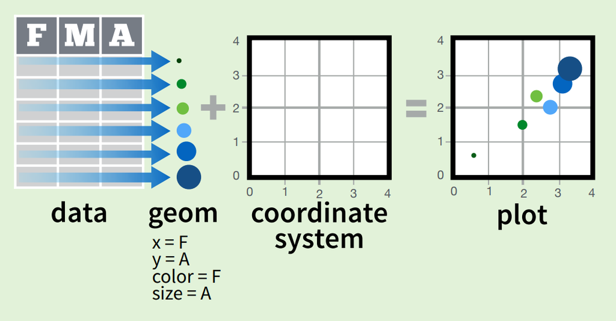

# Geoms

## Aesthetic mappings

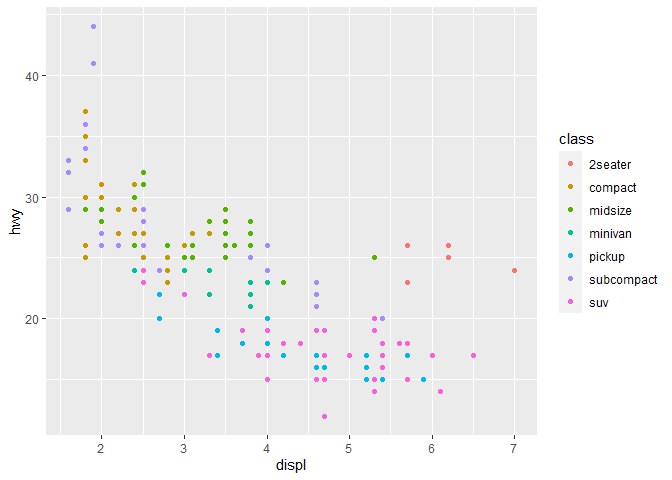

```r
ggplot(data = mpg) +
  geom_point(mapping = aes(x = displ, y = hwy, color = class))
```

### Manual setting of an aesthetic

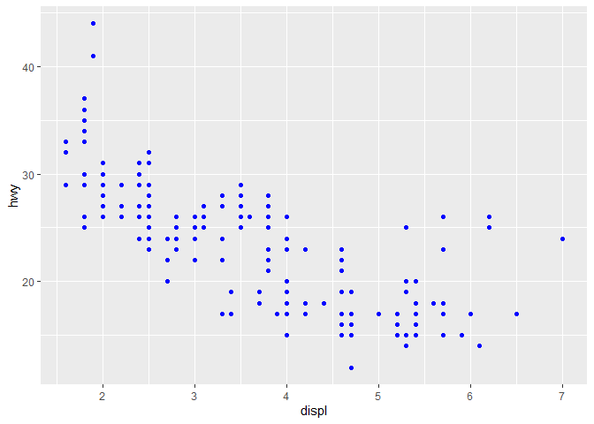

```r
ggplot(data = mpg) +
  geom_point(mapping = aes(x = displ, y = hwy), color = "blue")
```

## Statistical transformations

Some plots visualize a transformation of the original data set. Use a `stat` to choose a common transformation to visualize.

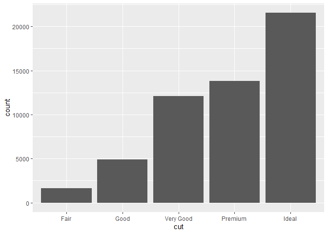

```r
ggplot(data = diamonds) +
  stat_count(mapping = aes(x = cut))  # every stat has a default geom
```

`stat` functions and `geom` functions both combine a stat with a geom to make a layer, i.e. `stat_bin(geom="bar")` does the same as `geom_bar(stat="bin")`.

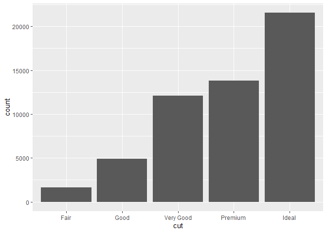

```r
ggplot(data = diamonds) +
  geom_bar(mapping = aes(x = cut))  # and every geom has a default stat
```

Each stat creates additional variables to map aesthetics to. These variables use a common `..name..` syntax.

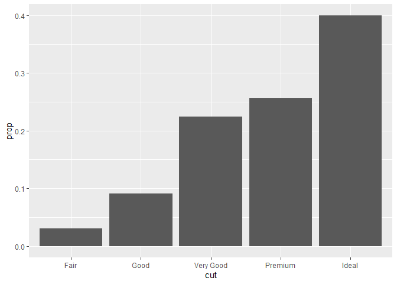

```r
ggplot(data = diamonds) +
  geom_bar(mapping = aes(x = cut, y = ..prop.., group = 1))
```

## Position adjustments

You’ve learned various position adjustments in class, such as

- `"identity"`
- `"dodge"`
- `"stack"`
- `"fill"`
- `"jitter"`

## Multiple geoms in a graph

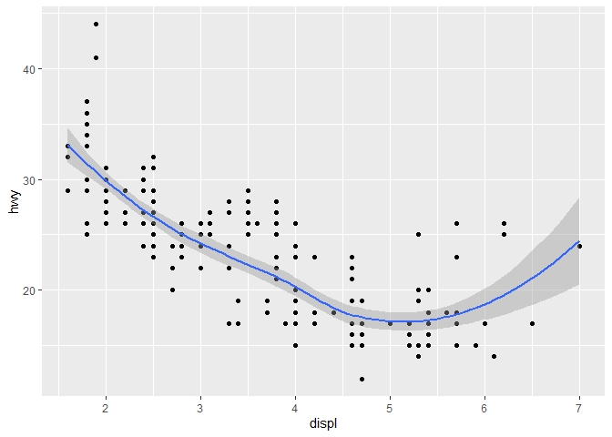

```r
ggplot(data = mpg) +
  geom_point(mapping = aes(x = displ, y = hwy)) +
  geom_smooth(mapping = aes(x = displ, y = hwy))
```

Note that following code will give exactly same graph:

```r
ggplot(data = mpg, mapping = aes(x = displ, y = hwy)) +  # set global mappings
  geom_point() + geom_smooth()
```

## Overriding

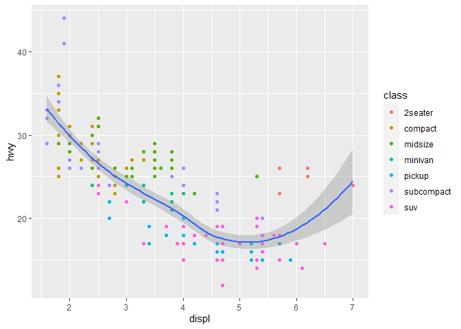

```r
ggplot(data = mpg, mapping = aes(x = displ, y = hwy)) +
  geom_point(mapping = aes(color = class)) +  # override default aesthetics
  geom_smooth()
```

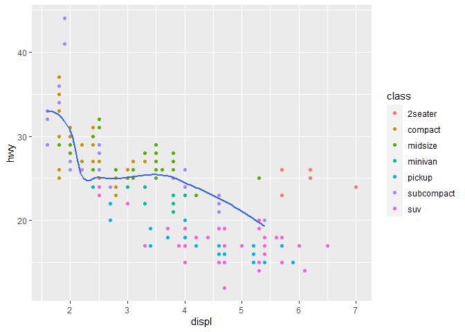

```r
ggplot(data = mpg, mapping = aes(x = displ, y = hwy)) +
  geom_point(mapping = aes(color = class)) +
  geom_smooth(data = filter(mpg, class == "subcompact"), se = FALSE)  # you can also override data
```

# Coordinate

# Facet

Facets divide a plot into subplots based on the values of one or more discrete variables. You’ve learned various facet functions in class, such as

- `facet_wrap`
- `facet_grid`

# Graphics for communications

## Labels

You can add labels via `labs()` function.

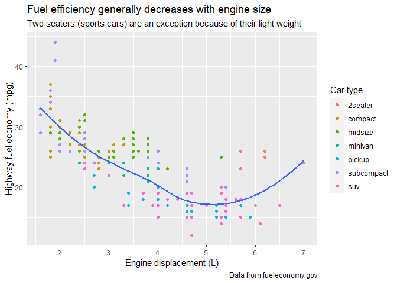

```r
ggplot(mpg, aes(displ, hwy)) +
  geom_point(aes(color = class)) +
  geom_smooth(se = FALSE) +
  labs(
    title = "Fuel efficiency generally decreases with engine size",
    subtitle = "Two seaters (sports cars) are an exception because of their light weight",
    caption = "Data from fueleconomy.gov",
    x = "Engine displacement (L)",
    y = "Highway fuel economy (mpg)",
    colour = "Car type"
  )
```

You can put math equations. See `?plotmath` for more infos.

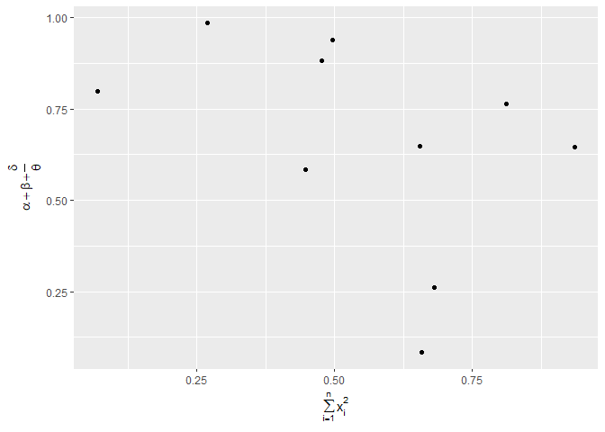

```r
df <- tibble(x = runif(10), y = runif(10))
ggplot(df, aes(x, y)) + geom_point() +
  labs(
    x = quote(sum(x[i] ^ 2, i == 1, n)),
    y = quote(alpha + beta + frac(delta, theta))
  )
```

## Annotations

```r
best_in_class <- mpg %>%
  group_by(class) %>%
  filter(row_number(desc(hwy)) == 1)
best_in_class
```

```
## # A tibble: 7 x 11
## # Groups:   class [7]
##   manufacturer model     displ  year   cyl trans  drv     cty   hwy fl    class
##   <chr>        <chr>     <dbl> <int> <int> <chr>  <chr> <int> <int> <chr> <chr>
## 1 chevrolet    corvette    5.7  1999     8 manua~ r        16    26 p     2seat~
## 2 dodge        caravan ~   2.4  1999     4 auto(~ f        18    24 r     miniv~
## 3 nissan       altima      2.5  2008     4 manua~ f        23    32 r     midsi~
## 4 subaru       forester~   2.5  2008     4 manua~ 4        20    27 r     suv
## 5 toyota       toyota t~   2.7  2008     4 manua~ 4        17    22 r     pickup
## 6 volkswagen   jetta       1.9  1999     4 manua~ f        33    44 d     compa~
## 7 volkswagen   new beet~   1.9  1999     4 manua~ f        35    44 d     subco~
```

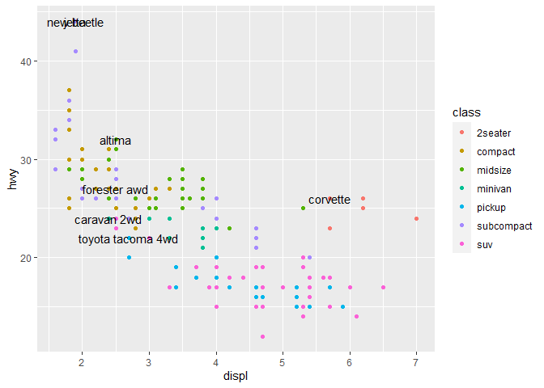

```r
ggplot(mpg, aes(x = displ, y = hwy)) +
  geom_point(aes(colour = class)) +
  geom_text(aes(label = model), data = best_in_class)
```

Using `ggrepel` package automatically adjust labels so that they don’t overlap.

## Scales

`scale` functions control how a plot maps data values to the visual values of an aesthetic.

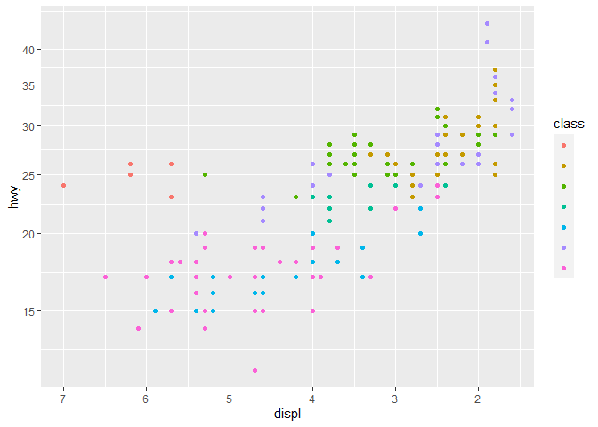

```r
ggplot(mpg, aes(displ, hwy)) +
  geom_point(aes(colour = class)) +
  scale_x_reverse() +
  scale_y_log10(breaks = seq(15, 40, by = 5)) +
  scale_colour_discrete(labels = NULL)
```

## Legends

To control the overall position of the legend, you need to use a `theme()` setting.

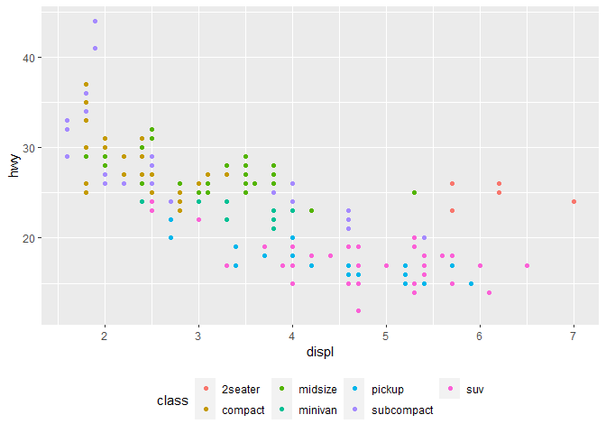

```r
ggplot(mpg, aes(displ, hwy)) +
  geom_point(aes(colour = class)) +
  theme(legend.position = "bottom")
```

## Zooming

Methods to control the plot limits:

1. Setting `xlim` and `ylim` in `coord_cartesian()` (without clipping)

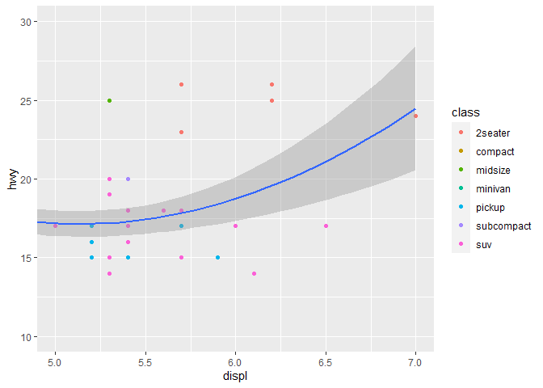

   ```r
   ggplot(mpg, mapping = aes(displ, hwy)) +
     geom_point(aes(color = class)) +
     geom_smooth() +
     coord_cartesian(xlim = c(5, 7), ylim = c(10, 30))
   ```

2. Setting the limits in each scale (with clipping; i.e. removes unseen data points)

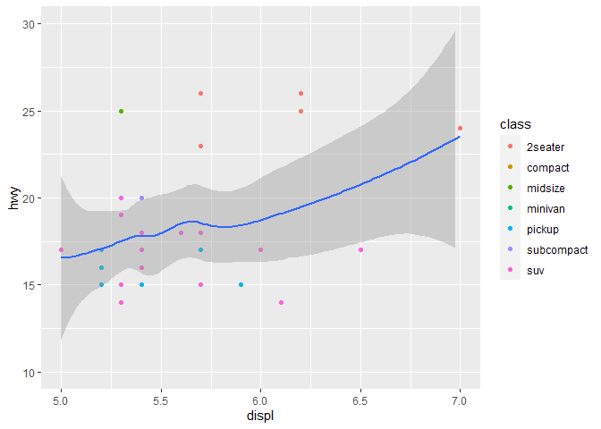

   ```r
   ggplot(mpg, mapping = aes(displ, hwy)) +
     geom_point(aes(color = class)) +
     geom_smooth() +
     xlim(5, 7) + ylim(10, 30)
   ```

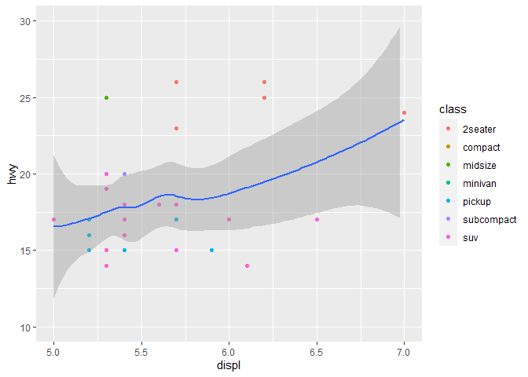

   ```r
   ggplot(mpg, mapping = aes(displ, hwy)) +
     geom_point(aes(color = class)) +
     geom_smooth() +
     scale_x_continuous(limits = c(5, 7)) +
     scale_y_continuous(limits = c(10, 30))
   ```

3. Adjusting what data are plotted (manual clipping)

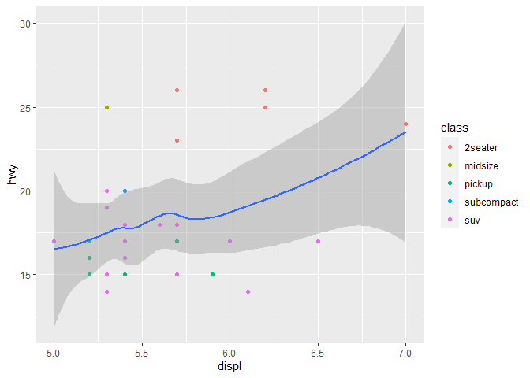

   ```r
   mpg %>%
     filter(displ >= 5, displ <= 7, hwy >= 10, hwy <= 30) %>%
     ggplot(aes(displ, hwy)) +
     geom_point(aes(color = class)) +
     geom_smooth()
   ```

## Theme

You can customise the non-data elements of your plot with a theme.

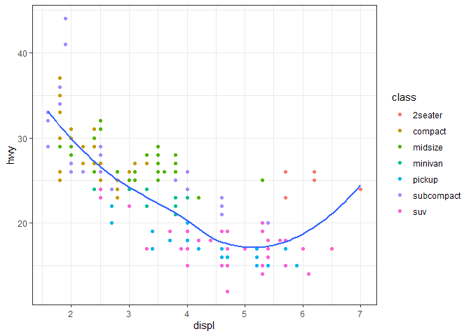

```r
ggplot(mpg, aes(displ, hwy)) +
  geom_point(aes(color = class)) +
  geom_smooth(se = FALSE) +
  theme_bw()
```

ggplot2 has eight built-in themes. Many more themes are included in add-on packages like `ggthemes`.

### Exercise

**Reproduce the following plots as exactly as possible. Do not change size, alpha, and coordinate range from the default setting.**

```r
wine <- read_csv("./wine.csv")
```

**a) Scatter plot showing relationship of residual_sugar, volatile_acidity, and quality for each type of wine. All axes are in log scale.**

(Hint: use ‘scale_x_log10()’,‘scale_x_log10()’ and ‘facet_wrap(~type, nrow = )’

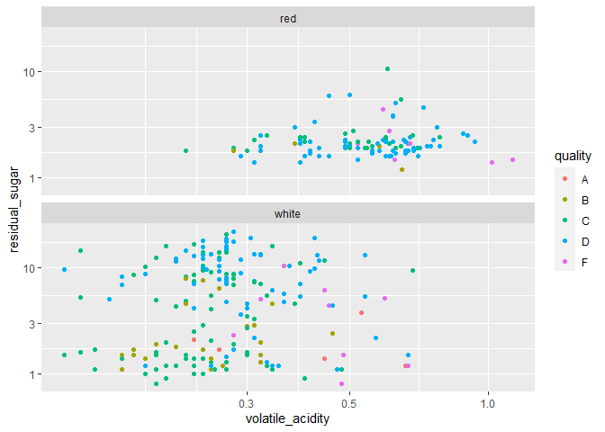

**b) Histogram showing distribution of qualities for each type of wine**

(Hint: use ‘geom_bar(aes(x = , fill = quality), position = “dodge”)’,‘coord_flip()’, ‘labs(x = , y = , title = , subtitle = )’ and ‘theme(legend.position = )’

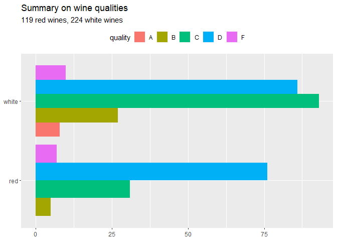

**Acknowledgment** All contents in this note is based on the book “R for Data Science”, written by Grolemund & Wickham.